# Alignments

I used Bowtie2 to align whole genome sequences of stickleback to the Glazer reference. I used Samtools to sort, index, and filter by whether MAPQ score ≥ 20

```bash
cd /lustre1/jcfuller/stick/genome/fastq/stickleback_fastq/${sample}

# Align
export read1_list=`ls -m *_1.fastq.gz | tr -d ' \n'`

module load bowtie2/latest
shopt -s nullglob
set -- *_2.fastq.gz
if [ "$#" -gt 0 ]
  then
      export read2_list=`ls -m *_2.fastq.gz | tr -d ' \n'`
      bowtie2 -p ${cores} --no-unal --very-sensitive -x /lustre1/jcfuller/stick/genome/bowtie/Glazer/Glazer \
      -1 ${read1_list} \
      -2 ${read2_list} \
      --rg-id ${sample}_${runNum} \
      --rg SM:${sample} \
      --rg PL:ILLUMINA \
      --rg LB:${runNum} \
      -S /lustre1/jcfuller/stick/genome/sam/${sample}.sam \
      >& ${sample}_${runNum}_summary.txt

  else
      bowtie2 -p ${cores} --no-unal --very-sensitive -x /lustre1/jcfuller/stick/genome/bowtie/Glazer/Glazer \
      -U ${read1_list} \
      --rg-id ${sample}_${runNum} \
      --rg SM:${sample} \
      --rg PL:ILLUMINA \
      --rg LB:${runNum} \
      -S /lustre1/jcfuller/stick/genome/sam/${sample}.sam \
      >& ${sample}_${runNum}_summary.txt
fi

# Sort, index
module load samtools/latest
cd /lustre1/jcfuller/stick/genome/sam
samtools view -bh -@ $(expr ${cores} - 1) ${sample}.sam > ${sample}.bam
samtools sort -o ${sample}_sorted.bam -T ${sample}_s -@ ${cores} ${sample}.bam
mv ${sample}_sorted.bam ${sample}.bam
samtools index -b ${sample}.bam

# Filter by whether MAPQ score ≥ 20
if [ ${mapFilter} = true ]
then
    samtools view -bh -q 20 -@ $(expr ${cores} - 1) ${sample}.bam > ${sample}_q.bam
    samtools index -b ${sample}_q.bam
fi
```

# Acquiring Read Depth from Specific Chromosomes

You can use the Samtools “view” command with a specified range to view a section of the .bam file. I did this, and piped the result into the Bedtools “genomecov” command, with the -d option that produces the read depth at every basepair position. You must use bedtools v. 2.24.0 for this to work. V. 2.25.0 (on Sapelo) doesn’t work as expected (unsure why). I’m only interested in the 3rd column of the bedtools results, so I pipe that into a output file.

```bash
#On UGA's Sapelo

module load samtools/1.2
#bedtools v. 2.25.0 causes weird issues
module unload bedtools/2.25.0
module load bedtools/2.24.0

samtools view -b ${sample}.bam chrXXI | \
bedtools genomecov \
  -d \
  -ibam stdin | \
  awk '{print $3}' >> ${sample}_XXI_depth.txt
```

# Sliding Window Averages of Raw Read Depth

Using a python program developed by Lucas Nell (https://github.com/lucasnell/MAW_Misc/blob/master/slidWin.py), I was able to find the a sliding window average of the read depths. The window size was 1000bp, and it moved along the chromosome in 500 bp increments. For chrXIX, this is 41225 values. For chrXXI, this is 34715 values.

# plot

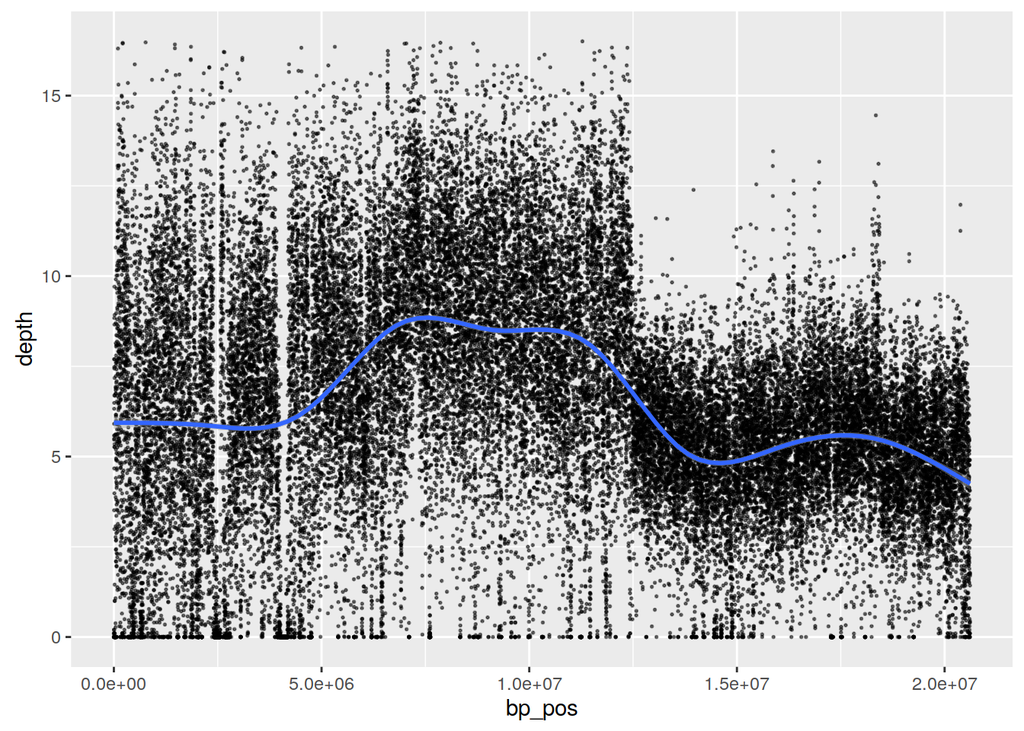